# Fungal community analysis

ANSC 595

3/26/2020

A very interesting and more novel type of analysis is to describe the composition of the fungal community. Nowadays, bacterial community analysis is completed in maybe 99% of the studies. The fungal community, while less abundant can perform functions bacteria cannot. Those that perform studies with both bacterial and fungal communities and other classes of organisms get a better idea of the microbial community. Keep in mind the seminar from Mary Firestone

This type of analysis is still fairly rare and the documentation is not as complete as for bacterial analysis. I found 1 tutorial I like for both mothur and qiime2. They are

**For mothur:**  
https://github.com/biocorecrg/microbiome_procedures/blob/master/README_mothur_ITS.txt

**For qiime2:**  
https://github.com/gregcaporaso/2017.06.23-q2-fungal-tutorial

Today we will use qiime2 because we need some more time with the qiime pipeline to help you learn it better.

To complete the fungal analysis, the key thing that is different is the database file. For bacterial communities, we use Silva as our database to assign taxonomies to our obtained sequences. For fungal communities, it seems like the UNITE database has established itself as a leader in fungal taxonomy. Here is a paper describing the UNITE database

*Towards a unified paradigm for sequence-based identification of fungi*  
[link to paper](https://onlinelibrary.wiley.com/doi/pdf/10.1111/mec.12481)

The tutorial by Greg Caporaso uses an **old** version of the UNITE database, and there are some links that don’t work, so I will walk you through where and how to get the database files, because this was not very clear to me to figure it out.

To get database files formatted for mothur or qiime go to this address.  
https://unite.ut.ee/repository.php

You will see that there are options for mothur or qiime.

[figure not shown]

Each terminal fungal taxon for which two or more ITS sequences are available is referred to as a species hypothesis (SH). One sequence is chosen to represent each SH; these sequences are called representative sequences (RepS) when chosen automatically by the computer and reference sequences (RefS) when those choices are overridden (or confirmed) by users with expert knowledge of the taxon at hand.

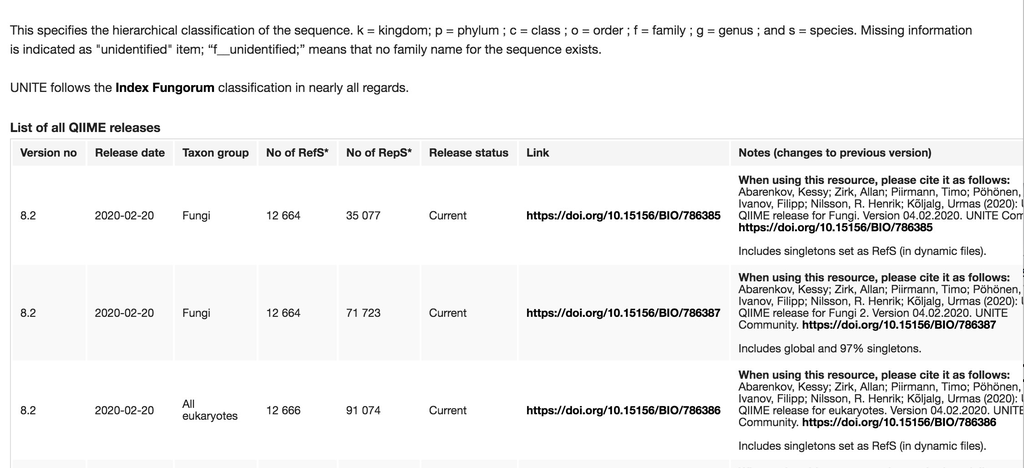

I’m not 100% sure of the differences between these databases. It seems that the second version of UNITE database that is listed is 2x bigger because it includes SHs that contain only one sequence (ie. singletons). They both have the same number of RefS’s. We will use the smaller database.

Follow these links to get the database file.

**Step 1**

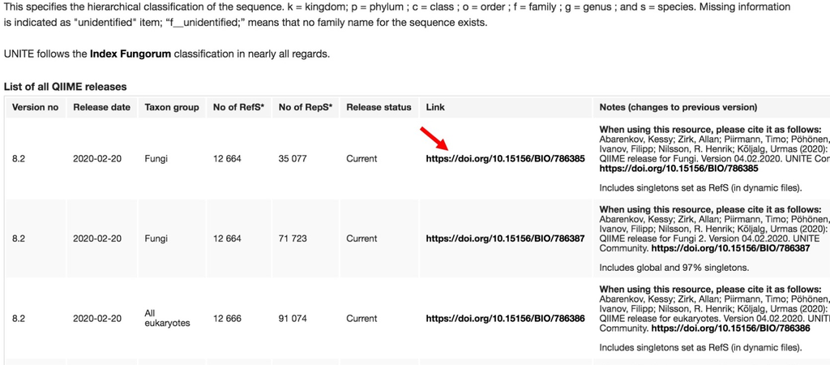

**Step 2**

[figure not shown]

**Step 3**

[figure not shown]

Notice in that last screenshot that it says the File name is `sh_qiime_release_04.02.2020.tar.gz`. But the thing that we are going to download is called `https://files.plutof.ut.ee/public/orig/98/AE/98AE96C6593FC9C52D1C46B96C2D9064291F4DBA625EF189FEC1CCAFCF4A1691.gz`. This file is actually a `.tar.gz` even though the name only has `.gz`. This is going to be important. So the next thing we are going to do is get started on the cluster.

###Logging into the cluster

####On a mac

Open Terminal and type:

```
$ ssh user.name@bell.rcac.purdue.edu
```

And enter your password.

####On a PC

Use Putty and enter

```
bell.rcac.purdue.edu
```

in the Host name space. Make sure ssh is selected

###You should now be on the cluster.

It would be best to start an interactive session at this point.

```
$ slist                         #Check availability
$ squeue                        #Who is using how many resources?
$ sinteractive -A microbiome -n12 -t 2:00:00
```

####Download the database

So we will use the address we found on the UNITE website to download the files to the cluster:

```
$ cd $RCAC_SCRATCH
$ cd qiime
$ mkdir fungal_ITS
$ cd fungal_ITS
$ wget https://files.plutof.ut.ee/public/orig/98/AE/98AE96C6593FC9C52D1C46B96C2D9064291F4DBA625EF189FEC1CCAFCF4A1691.gz
```

Now we need to decompress that file. You use `gunzip` to decompress a `.gz` file, but this is a `.tar.gz` file.

```
$ tar -xzf 98AE96C6593FC9C52D1C46B96C2D9064291F4DBA625EF189FEC1CCAFCF4A1691.gz
$ ls
```

You should now see that you have the `sh_qiime_release_04.02.2020` directory that resulted from decompressing the `.tar.gz` file and it has the **same name** as indicated on the UNITE website! Excellent! This was the hardest thing for me to figure out.

The next thing to figure out is how to make these files work in qiime2. There is a write up in the qiime2 tutorials about `Training feature classifiers with q2-feature-classifier` available at https://docs.qiime2.org/2020.2/tutorials/feature-classifier/. At the very bottom is the section on *Fungal databases*. This is the same website you will consult if you are using a region of the 16S gene other than the V4 region. From this section

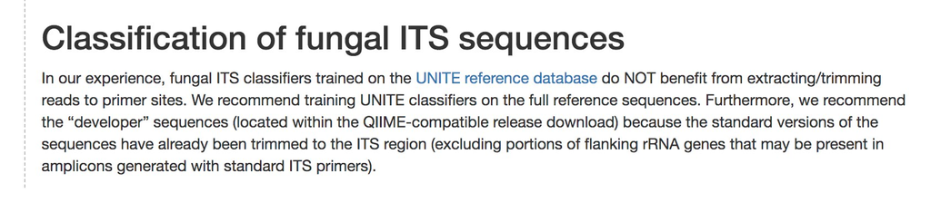

We learn a couple important things:

1. Do not trim the reference sequences specific to your primer location. This means we only need one classifier for any ITS primer set. This is contrary to what we do for bacterial databases.
2. We need to use the *developer* version of the database.

As much as I would like to use the developer version, there are issues with the files that do not allow it to be imported, so we will use the regular version. I think it will be fine.

If we look at the directories we have

```
$ ls sh_qiime_release_04.02.2020
#notice that "developer" is listed, but we aren't going there.
```

From here we see six files:

1-3 are fasta files with actual reference sequences 4-6 are the taxonomies of those sequences

There are three of each because there are three levels of clustering or specificity to determine SHs. The Caporaso tutorial uses the 99% clustering version. We’ll just go ahead with that one. The dynamic one is not strict on a percent cutoff, but they use the knowledge the experts have in fungal taxonomies to divide them into “species hypotheses”.

Now we will adapt the code on the Caporaso tutorial to these most current database files. There are three steps.

1. Make a qiime artifact from the database fasta file
2. Make a qiime artifact from the database taxonomy file
3. Combine the output from #1 and #2 to make a qiime “classifier”

**DO NOT EXECUTE THESE LINES:** Now we are **NOT** going to run this in the interactive job. We are going to submit to the **scheduler**.

```
qiime tools import \
 --type FeatureData[Sequence] \
 --input-path sh_refs_qiime_ver8_99_04.02.2020.fasta \
 --output-path unite-ver8_99_seqs_04.02.2020.qza
```

```
qiime tools import \
 --type FeatureData[Taxonomy] \
 --input-path sh_taxonomy_qiime_ver8_99_04.02.2020.txt \
 --output-path unite-ver8_99_tax_04.02.2020.qza \
 --input-format HeaderlessTSVTaxonomyFormat
```

```
qiime feature-classifier fit-classifier-naive-bayes \
 --i-reference-reads unite-ver8_99_seqs_04.02.2020.qza \
 --i-reference-taxonomy unite-ver8_99_tax_04.02.2020.qza \
 --o-classifier unite-ver8-99-classifier-04.02.2020.qza
```

**Why should you strive to always use the scheduler and not the interactive session**

1. When you run interactive you are relying on your internet connection between your computer and the cluster. If this connection is interrupted even for a short time, the job will be killed.
2. When you are running the analysis for your project the processes will take much longer than the tutorials because the tutorial datasets were purposefully small.
3. When you submit to the scheduler, you can request more cpus to ensure you have enough computational power and to make it go faster
4. Both your terminal and computer are free to do other things or can be shut down.
5. The job submission file can also serve as your lab journal to build your analysis pipeline. I wouldn’t immediately list all the commands all at once and tell it to run. You will probably get an error and it will be hard to troubleshoot. So I would add 1 command at a time, and test it.

```
$ cp /depot/microbiome/data/qiime/fungal_ITS/*.slurm .

#lets go ahead and submit this job. It will take 14 mintues
$ sbatch qiime_classifier.slurm

#to see if its running
$ squeue -u user_name

#to see standard output
$ ls
$ less slurm-XXXX.out

#lets look at the contents of this file
$ less qiime_classifier.slurm
```

```
#!/bin/sh -l

#SBATCH --nodes=1                   ##number of requested nodes (a node is a group of CPUs)
#SBATCH --tasks-per-node=20         ##number of requested CPUs
#SBATCH --time=02:00:00             ##time requested
#SBATCH --job-name qiime_classifier ##name of job
#SBATCH -A microbiome                  ##name of the queue you are using.

#########################################################################
#step 1, cd into the proper directory

cd $RCAC_SCRATCH
cd qiime/fungal_ITS/sh_qiime_release_04.02.2020/

pwd

#step 2, Load Modules

echo "loading bioinfo"
module load bioinfo

echo "loading qiime2-2020.2"
module load Qiime/2-2020.2

echo "Start time"
date +"%d %B %Y %H:%M:%S"

echo "initiating qiime2 classifier pipeline"

#step 3, run your process
#import fasta sequences into qiime
qiime tools import \
 --type FeatureData[Sequence] \
 --input-path sh_refs_qiime_ver8_99_04.02.2020.fasta \
 --output-path unite-ver8_99_seqs_04.02.2020.qza

#import taxonomy file into qiime
qiime tools import \
 --type FeatureData[Taxonomy] \
 --input-path sh_taxonomy_qiime_ver8_99_04.02.2020.txt \
 --output-path unite-ver8_99_tax_04.02.2020.qza \
 --input-format HeaderlessTSVTaxonomyFormat

#merge the sequence and taxonomy .qzas into a classifier object
qiime feature-classifier fit-classifier-naive-bayes \
 --i-reference-reads unite-ver8_99_seqs_04.02.2020.qza \
 --i-reference-taxonomy unite-ver8_99_tax_04.02.2020.qza \
 --o-classifier unite-ver8-99-classifier-04.02.2020.qza

echo " "

echo "End time"
date +"%d %B %Y %H:%M:%S"

#to run: sbatch qiime_classifier.slurm
```

Now we need to get some fungal sequences

```
wget -O "mock-25-sample-metadata.tsv" https://raw.githubusercontent.com/caporaso-lab/mockrobiota/master/data/mock-25/sample-metadata.tsv

wget https://s3-us-west-2.amazonaws.com/mockrobiota/latest/mock-25/mock-forward-read.fastq.gz
```

Create a file, fastqmanifest.csv, with the following two lines:

```
sample-id,absolute-filepath,direction
Mock.1,$PWD/mock-forward-read.fastq.gz,forward
```

To do this:

```
$ nano fastqmanifest.csv
#copy and past the two lines in the white box above
```

Next we are going to submit the next two lines in a slurm

```
$ sbatch qiime_demux.slurm
```

This script has the following codes

**DO NOT RUN**

```
qiime tools import \
 --type SampleData[SequencesWithQuality] \
 --input-path fastqmanifest.csv \
 --output-path demux.qza \
 --input-format SingleEndFastqManifestPhred33

qiime demux summarize \
 --i-data demux.qza \
 --o-visualization demux.qzv
```

It is useful to look at demux.qzv to access the quality of your sequences. To do this you need to download them to your local computer. On a Mac, use the terminal on your local computer. On a Windows machine, use PowerShell or CommandPrompt

```
$ cd your/selected/path
$ scp john2185@scholar.rcac.purdue.edu:/scratch/scholar/john2185/qiime/fungal_ITS/demux.qzv .
```

Now drag that file that is now on you computer to view.qiime2.org

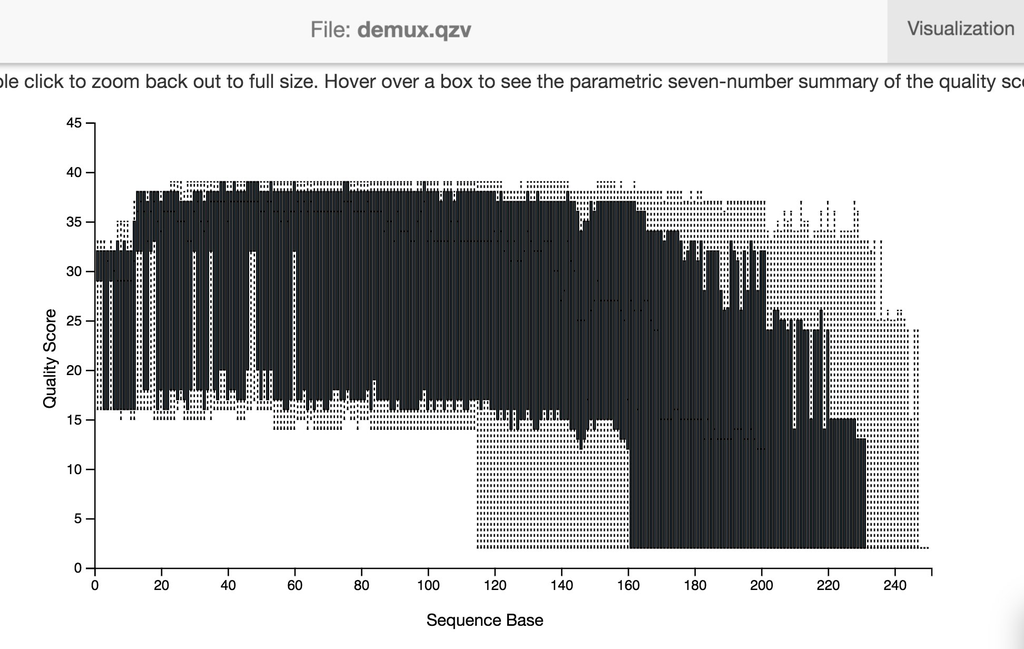

From this we see that we have some fairly low quality scores

So we will use the parameters indicated below for trimming the sequences. Again we have another slurm script to run the commands

```
$ sbatch qiime_barplot.slurm
```

This script has the following codes

**DO NOT RUN**

```
qiime dada2 denoise-single \
  --i-demultiplexed-seqs demux.qza \
  --p-trim-left 10 \
  --p-trunc-len 140 \
  --o-representative-sequences rep-seqs.qza \
  --o-table table.qza \
  --o-denoising-stats denoising-stats.qza

qiime feature-classifier classify-sklearn \
  --i-classifier sh_qiime_release_04.02.2020/unite-ver8-99-classifier-04.02.2020.qza \
  --i-reads rep-seqs.qza \
  --o-classification taxonomy.qza

qiime taxa tabulate \
  --m-input-file taxonomy.qza \
  --o-visualization taxonomy.qzv

qiime taxa barplot \
  --i-table table.qza \
  --i-taxonomy taxonomy.qza \
  --m-metadata-file mock-25-sample-metadata.tsv \
  --o-visualization taxa-bar-plots.qzv
```

The expected composition of this community can be found here: https://github.com/caporaso-lab/mockrobiota/blob/master/data/mock-25/unite/7-1/99-otus/expected-taxonomy.tsv